Authors: Tim Gorman, Yu Cao, Ling Zhou

Data analyzed in this notebook is from [Kaggle's code competation: Foursquare - Location Matching](https://www.kaggle.com/competitions/foursquare-location-matching/data). The data comprises over one-and-a-half million place entries for hundreds of thousands of commercial Points-of-Interest (POIs) around the globe.

```python
import pandas as pd
import numpy as np
import string
from sklearn.metrics.pairwise import cosine_similarity
from sklearn.feature_extraction.text import CountVectorizer
from nltk.corpus import stopwords
stopwords = stopwords.words('english')

# from googletrans import Translator, constants
import seaborn as sns
import matplotlib.pyplot as plt

from shapely.geometry import Point
from geopandas import GeoDataFrame
import geopandas as gpd

import langdetect
from langdetect import detect

# Note: To install geopandas, open a terminal in jupyter and run the following commands

# pip install pipwin
# pipwin install gdal
# pipwin install fiona
# pip install geopandas
```

# Exploring `train.csv`

## Basic information

The official description from [Kaggle](https://www.kaggle.com/competitions/foursquare-location-matching/data):

This set comprises eleven attribute fields for over one million place entries, together with:

- `id` - A unique identifier for each entry.
- `point_of_interest` - An identifier for the POI the entry represents. There may be one or many entries describing the same POI. Two entries "match" when they describe a common POI.

  This data set is large (1138812 entries). Later we will decide only work with the file `pairs.csv` for our modeling.

```python
# loading data
df_train = pd.read_csv("../data_raw/train.csv")
```

```python
df_train.info()
```

```
<class 'pandas.core.frame.DataFrame'>
RangeIndex: 1138812 entries, 0 to 1138811
Data columns (total 13 columns):
 #   Column             Non-Null Count    Dtype
---  ------             --------------    -----
 0   id                 1138812 non-null  object
 1   name               1138811 non-null  object
 2   latitude           1138812 non-null  float64
 3   longitude          1138812 non-null  float64
 4   address            742191 non-null   object
 5   city               839623 non-null   object
 6   state              718226 non-null   object
 7   zip                543386 non-null   object
 8   country            1138801 non-null  object
 9   url                267724 non-null   object
 10  phone              342855 non-null   object
 11  categories         1040505 non-null  object
 12  point_of_interest  1138812 non-null  object
dtypes: float64(2), object(11)
memory usage: 112.9+ MB
```

```python
df_train.head()
```

|  | id | name | latitude | longitude | address | city | state | zip | country | url | phone | categories | point_of_interest |
| --- | --- | --- | --- | --- | --- | --- | --- | --- | --- | --- | --- | --- | --- |
| 0 | E_000001272c6c5d | Café Stad Oudenaarde | 50.859975 | 3.634196 | Abdijstraat | Nederename | Oost-Vlaanderen | 9700 | BE | NaN | NaN | Bars | P_677e840bb6fc7e |
| 1 | E_000002eae2a589 | Carioca Manero | -22.907225 | -43.178244 | NaN | NaN | NaN | NaN | BR | NaN | NaN | Brazilian Restaurants | P_d82910d8382a83 |
| 2 | E_000007f24ebc95 | ร้านตัดผมการาเกด | 13.780813 | 100.484900 | NaN | NaN | NaN | NaN | TH | NaN | NaN | Salons / Barbershops | P_b1066599e78477 |
| 3 | E_000008a8ba4f48 | Turkcell | 37.844510 | 27.844202 | Adnan Menderes Bulvarı | NaN | NaN | NaN | TR | NaN | NaN | Mobile Phone Shops | P_b2ed86905a4cd3 |
| 4 | E_00001d92066153 | Restaurante Casa Cofiño | 43.338196 | -4.326821 | NaN | Caviedes | Cantabria | NaN | ES | NaN | NaN | Spanish Restaurants | P_809a884d4407fb |

```python
df_train.shape
```

```
(1138812, 13)
```

## Missing values

- No missing values in the features: `id`, `latitude`, `longitude`, `point_of_interest`(POI)
- All other features have missing values
- Features with most missing values (top 3): `url`, `phone`, `zip`.
- only one missing value in `name`

```
id                    0.000000
latitude              0.000000
longitude             0.000000
point_of_interest     0.000000
name                  0.000088
country               0.000966
categories            8.632417
city                 26.272027
address              34.827610
state                36.931996
zip                  52.284837
phone                69.893626
url                  76.490940
dtype: float64
```

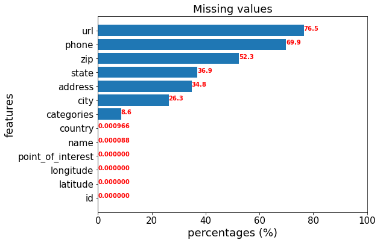

```python
df = df_train.copy()
# Count the missing values in each feature
missing = df.isna().sum()/df.shape[0]*100
print(missing.sort_values())

# Plot the percentages of missing values for each feature
import matplotlib.ticker as mtick
tmp = df.isna().sum().sort_values()
fig, ax = plt.subplots(figsize=(8,6))

y = tmp/len(df)*100
ax.barh(tmp.index, y)
ax.set_title("Missing values", fontsize=18)
# ax.axvline(x=60,color='r',linestyle='--')
# ax.xaxis.set_major_formatter(mtick.PercentFormatter())
ax.tick_params(axis='both', labelsize=15 )
ax.set_ylabel('features', fontsize=18)
ax.set_xlabel('percentages (%)', fontsize=18)
ax.set_xlim(0,100)

for index, value in enumerate(y):
    if value < 1:
        ax.text(value, index, '{:.6f}'.format(value), color = 'red', fontweight = 'bold')
    else:
        ax.text(value, index, '{:.1f}'.format(value), color = 'red', fontweight = 'bold')
plt.show()
```

## Features in `train.csv`

- We verify that the `id` feature is indeed a unique identifier for each entry.
- We explore in this section the features that have fewer missing values:
  - latitude and longitude
  - name
  - country
  - point_of_interest
- We explore entries that have the same POI.

```python
print(df.columns.values)
```

```
['id' 'name' 'latitude' 'longitude' 'address' 'city' 'state' 'zip'
 'country' 'url' 'phone' 'categories' 'point_of_interest']
```

### `id` (no missing values)

```python
# each value in `id` is indeed unique.
print("Each value in `id` is unique:", len(df.id.unique()) == df.shape[0])
```

```
Each value in `id` is unique: True
```

### `latitude` and `longitude` (no missing values)

```python
# # fancy plot
# geometry = [Point(xy) for xy in zip(df['longitude'], df['latitude'])]
# gdf = GeoDataFrame(df_train.copy(), geometry=geometry)

# #this is a simple map that goes with geopandas
# world = gpd.read_file(gpd.datasets.get_path('naturalearth_lowres'))
# fig, ax = plt.subplots(figsize=(20, 12))
# world.plot(figsize=(20, 12), ax=ax)
# gdf.plot(ax=ax, marker='o', color='red', markersize=10)

# fig.savefig("./train_coords.png")
# plt.show()
```

### `name`

This column has different languages.

#### How many languages are present in `name`?

We sample 10K names and find that roughly 20% of the sampled data is in English. The second most frequent language is about less than 8%.

```python
def lang_detect(x):
    ''' language detect with exception handling '''

    try:
        return detect(x)
    except:
        # print names that cause exception.
        print(x,end=' ')
        return np.nan

df = df_train.copy()
tmp = df['name'].sample(10000).fillna('').str.replace('[{}]'.format(string.punctuation),'',regex=True).str.lower()
lang_sample = tmp.apply(lang_detect)
```

```
711 22
```

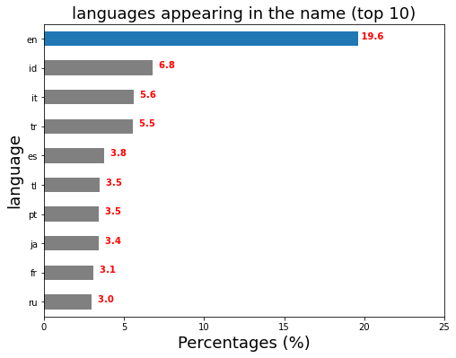

```python
lang_stats = lang_sample.value_counts()*100/lang_sample.value_counts().sum()
lang_stats = lang_stats.head(10).sort_values()

fig, ax = plt.subplots(figsize=(8,6))
color = ["gray"]*len(lang_stats.index)
color[-1] = '#1f77b4'
lang_stats.plot(kind = 'barh', ax = ax, color = color)

ax.set_title("languages appearing in the name (top 10)", fontsize = 18)
ax.set_ylabel('language', fontsize = 18)
ax.set_xlabel('Percentages (%)', fontsize = 18)
for index, value in enumerate(lang_stats.values):
    if value < 1:
        ax.text(value, index, '{:.6f}'.format(value), color = 'red', fontweight = 'bold')
    else:
        ax.text(value, index, '{:5.1f}'.format(value), color = 'red', fontweight = 'bold')
ax.set_xlim(0,25)
plt.show()
```

### `country`

Data availability in the `country` feature.

```
(10,)
```

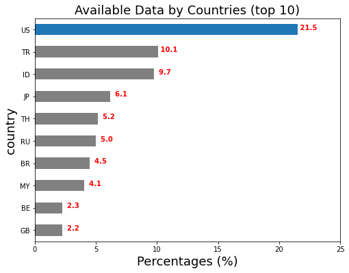

```python
df = df_train.copy()
country_stats = df['country'].value_counts()*100/df['country'].value_counts().sum()
country_stats = country_stats.head(10).sort_values()
print(country_stats.shape)

fig, ax = plt.subplots(figsize=(8,6))
color = ["gray"]*len(country_stats.index)
color[-1] = '#1f77b4'
country_stats.plot(kind = 'barh', ax = ax, color = color)

ax.set_title("Available Data by Countries (top 10)", fontsize = 18)
ax.set_ylabel('country', fontsize = 18)
ax.set_xlabel('Percentages (%)', fontsize = 18)
for index, value in enumerate(country_stats.values):
    if value < 1:
        ax.text(value, index, '{:.6f}'.format(value), color = 'red', fontweight = 'bold')
    else:
        ax.text(value, index, '{:5.1f}'.format(value), color = 'red', fontweight = 'bold')
ax.set_xlim(0,25)
plt.show()
```

### `point_of_interest`

Notes on the `point_of_interest` feature: https://www.kaggle.com/competitions/foursquare-location-matching/discussion/318967#1783581

```python
print('There are {} distinct POIs.'.format(df.point_of_interest.nunique()))
print('Abount {:.2f} %POIs are uniue'.format(df.point_of_interest.nunique()*100/df.point_of_interest.shape[0]))
```

```
There are 739972 distinct POIs.
Abount 64.98 %POIs are uniue
```

```python
most_freq_POI = df['point_of_interest'].value_counts().head(10)
most_freq_POI
```

```
P_fb339198a31db3    332
P_3a3fbd26e16269    199
P_f70a0977377171    166
P_9290e406eb58ac    145
P_fbe61733fcdebe    132
P_59cb47cbf3a432    130
P_f82d146eaf21da    120
P_40323f7f948c18    120
P_f8a0cd160eec80    119
P_6c385e5fd3a4b7    119
Name: point_of_interest, dtype: int64
```

```python
tmp = df[df['point_of_interest']==most_freq_POI.keys().values[0]].sort_values(by='name')
tmp.head()
```

|  | id | name | latitude | longitude | address | city | state | zip | country | url | phone | categories | point_of_interest |
| --- | --- | --- | --- | --- | --- | --- | --- | --- | --- | --- | --- | --- | --- |
| 89407 | E_140b5041aa4cd6 | "\"Sorkarno - Hatta Intl Airport, Indonesia\"" | -6.122573 | 106.725217 | Jl Raya Bandara | Tangerang | Indonesia | NaN | ID | NaN | NaN | Airports | P_fb339198a31db3 |
| 1115855 | E_fadb459e7f70ca | (CGK) Soekarno Hatta International Airport | -6.317134 | 106.805808 | NaN | NaN | NaN | NaN | ID | NaN | NaN | NaN | P_fb339198a31db3 |
| 545547 | E_7a97df0189d838 | @ Blue Bird Otw To Soeta | -6.229253 | 106.587979 | NaN | NaN | NaN | NaN | ID | NaN | NaN | NaN | P_fb339198a31db3 |
| 1086887 | E_f43a547c2bf278 | @ Jakarta International Airport Soekarno Hatta | -6.188795 | 106.814735 | Tangerang, Banten | NaN | NaN | NaN | ID | NaN | NaN | Airport Terminals | P_fb339198a31db3 |
| 703170 | E_9def7e6622aff9 | Airport | -6.226321 | 106.610071 | NaN | NaN | NaN | NaN | ID | NaN | NaN | NaN | P_fb339198a31db3 |

```python
tmp = df[df['point_of_interest']==most_freq_POI.keys().values[4]].sort_values(by='name')
tmp.head()
```

|  | id | name | latitude | longitude | address | city | state | zip | country | url | phone | categories | point_of_interest |
| --- | --- | --- | --- | --- | --- | --- | --- | --- | --- | --- | --- | --- | --- |
| 1113750 | E_fa600b778ee5b6 | 15 TEMMUZ ŞEHİRLER KÖPRÜSÜ Boğaziçi | 41.053444 | 29.025681 | NaN | NaN | NaN | NaN | TR | NaN | NaN | General Travel | P_fbe61733fcdebe |
| 205220 | E_2e0eabcf4f1fce | 15 TEMMUZ ŞEHİTLER KÖPRÜSÜ | 41.044080 | 29.035778 | ÜSKÜDAR | İSTANBUL | İstanbul | 34600 | TR | NaN | NaN | Toll Plazas | P_fbe61733fcdebe |
| 1113170 | E_fa3f089d94ab18 | 15 TEMMUZ ŞEHİTLER KÖPRÜSÜ | 41.066280 | 29.109200 | 15 TEMMUZ ŞEHİTLER KÖPRÜSÜ | İSTANBUL | İstanbul | 34830 | TR | NaN | NaN | Bus Stops | P_fbe61733fcdebe |
| 836015 | E_bbb9eece6631b4 | 15 Temmuz Şehitler Köprüsü | 41.045662 | 29.033861 | NaN | İstanbul | İstanbul | NaN | TR | NaN | NaN | Bridges | P_fbe61733fcdebe |
| 817814 | E_b7a8576db9ee44 | 15 Temmuz Şehitler Köprüsü | 41.045322 | 29.034568 | NaN | NaN | NaN | NaN | TR | NaN | NaN | Bridges | P_fbe61733fcdebe |

```python
tmp = df[df['point_of_interest']==most_freq_POI.keys().values[3]].sort_values(by='name')
tmp.head()
```

|  | id | name | latitude | longitude | address | city | state | zip | country | url | phone | categories | point_of_interest |
| --- | --- | --- | --- | --- | --- | --- | --- | --- | --- | --- | --- | --- | --- |
| 439624 | E_62cd73485781f1 | Demir Tekel | 41.041172 | 29.027612 | Ambarli Mh. Cumhuriyet Cd No 17 A | Avcilar | Istanbul | NaN | TR | NaN | NaN | Smoke Shops, Convenience Stores | P_9290e406eb58ac |
| 278777 | E_3e948439e48f45 | FutureIsNow@Ciftci Tekel Bayii | 41.007343 | 28.965347 | Mimar Kemalettin Mahallesi Mithatpasa Caddesi ... | Istanbul | NaN | NaN | TR | NaN | NaN | Smoke Shops | P_9290e406eb58ac |
| 315654 | E_46ef95847e0610 | FutureIsNow@Gunes Bufe | 41.009254 | 28.964443 | Mimar Kemalettin Mahallesi Darphane Sokak No:2... | Istanbul | NaN | NaN | TR | NaN | NaN | Convenience Stores | P_9290e406eb58ac |
| 793420 | E_b2346f54a52976 | FutureIsNow@Mini Market | 41.004417 | 28.975771 | NaN | NaN | NaN | NaN | TR | NaN | NaN | Convenience Stores | P_9290e406eb58ac |
| 902887 | E_cacdf23280dc06 | FutureIsNow@Rut 24 Tekel | 40.951267 | 29.098049 | Bostancı Mah. Bagdat Cad. No544 Kadiköy | Istanbul | NaN | NaN | TR | NaN | NaN | Convenience Stores | P_9290e406eb58ac |

# Exploring the US data in `train.csv`

```python
df_us = df[df['country']=='US'].copy()
```

```python
df_us.info()
```

```
<class 'pandas.core.frame.DataFrame'>
Int64Index: 245284 entries, 8 to 1138808
Data columns (total 13 columns):
 #   Column             Non-Null Count   Dtype
---  ------             --------------   -----
 0   id                 245284 non-null  object
 1   name               245283 non-null  object
 2   latitude           245284 non-null  float64
 3   longitude          245284 non-null  float64
 4   address            188824 non-null  object
 5   city               236241 non-null  object
 6   state              239373 non-null  object
 7   zip                213277 non-null  object
 8   country            245284 non-null  object
 9   url                99477 non-null   object
 10  phone              131597 non-null  object
 11  categories         232133 non-null  object
 12  point_of_interest  245284 non-null  object
dtypes: float64(2), object(11)
memory usage: 26.2+ MB
```

## Missing values

```
id                    0.000000
latitude              0.000000
longitude             0.000000
country               0.000000
point_of_interest     0.000000
name                  0.000408
state                 2.409860
city                  3.686747
categories            5.361540
zip                  13.048955
address              23.018216
phone                46.349130
url                  59.444155
dtype: float64
```

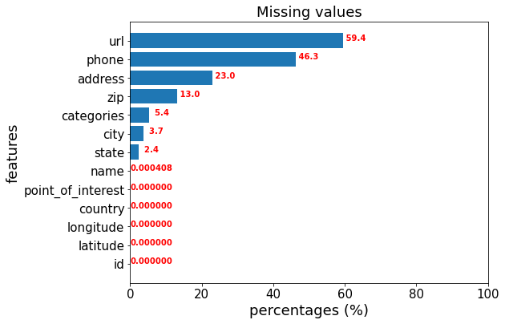

```python
df = df_us.copy()
# Count the missing values in each feature
missing = df.isna().sum()/df.shape[0]*100
print(missing.sort_values())

# Plot the percentages of missing values for each feature
import matplotlib.ticker as mtick
tmp = df.isna().sum().sort_values()
fig, ax = plt.subplots(figsize=(8,6))

y = tmp/len(df)*100
ax.barh(tmp.index, y)
ax.set_title("Missing values", fontsize=18)
# ax.axvline(x=60,color='r',linestyle='--')
# ax.xaxis.set_major_formatter(mtick.PercentFormatter())
ax.tick_params(axis='both', labelsize=15 )
ax.set_ylabel('features', fontsize=18)
ax.set_xlabel('percentages (%)', fontsize=18)
ax.set_xlim(0,100)

for index, value in enumerate(y):
    if value < 1:
        ax.text(value, index, '{:.6f}'.format(value), color = 'red', fontweight = 'bold')
    else:
        ax.text(value, index, '{:5.1f}'.format(value), color = 'red', fontweight = 'bold')
plt.show()
```

## Features

### `latitude` and `longitude`

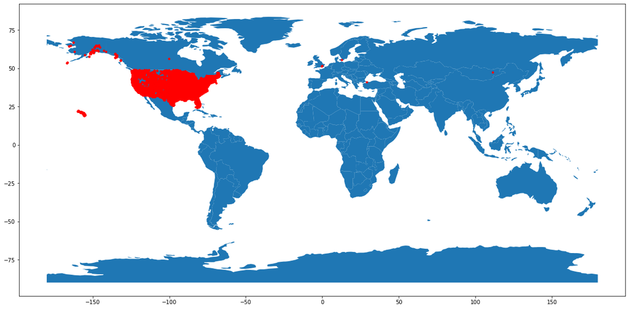

```python
# fancy plot
geometry = [Point(xy) for xy in zip(df['longitude'], df['latitude'])]
gdf = GeoDataFrame(df.copy(), geometry=geometry)

#this is a simple map that goes with geopandas
world = gpd.read_file(gpd.datasets.get_path('naturalearth_lowres'))
fig, ax = plt.subplots(figsize=(20, 12))
world.plot(figsize=(20, 12), ax=ax)
gdf.plot(ax=ax, marker='o', color='red', markersize=10)

fig.savefig("./train_coords_us.png")
plt.show()

# fig, ax = plt.subplots(figsize=(40,10))
# ax.scatter(df_us['longitude'],df_us['latitude'])
# ax.set_xlabel('longitude',fontsize=40)
# ax.set_ylabel('latitude',fontsize=40)
# ax.tick_params(axis='both', labelsize=40)
# ax.set_title('US data',fontsize=40)
# ax.grid()
# plt.show()
```

### `name`

```python
tmp = df_us['name'].sort_values()
tmp
```

```
622268                               "#208 \"Comfort Inn\""
769105                  "Access Health Care, LLC \"Adams\""
885613                 "Access Health Care, LLC \"Howell\""
779271    "Alfredo's Beach Club's \"Sunsets On The Beach...
493745                       "AmVets Post #2 \"Post Home\""
                                ...
150203                                   Kaleigh's Krib
513853                                              Heaven
121260                                  V Bar Ultra Lounge
474973                                   💇 Hair By CHiiNK 💋
750648                                                  NaN
Name: name, Length: 245284, dtype: object
```

```python
def lang_detect(x):
    ''' language detect with exception handling '''

    try:
        return detect(x)
    except:
        # print names that cause exception.
        print(x,end=' ')
        return np.nan

tmp = df['name'].sample(10000).fillna('').str.replace('[{}]'.format(string.punctuation),'',regex=True).str.lower()
lang_sample = tmp.apply(lang_detect)
```

```
34137
```

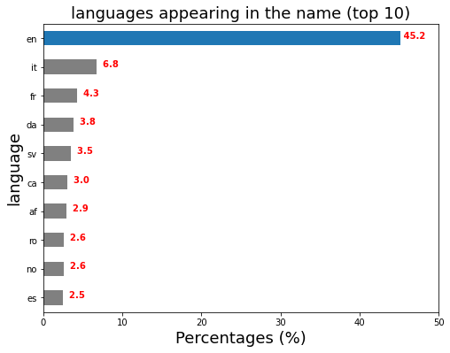

```python
lang_stats = lang_sample.value_counts()*100/lang_sample.value_counts().sum()
lang_stats = lang_stats.head(10).sort_values()

fig, ax = plt.subplots(figsize=(8,6))
color = ["gray"]*len(lang_stats.index)
color[-1] = '#1f77b4'
lang_stats.plot(kind = 'barh', ax = ax, color = color)

ax.set_title("languages appearing in the name (top 10)", fontsize = 18)
ax.set_ylabel('language', fontsize = 18)
ax.set_xlabel('Percentages (%)', fontsize = 18)
for index, value in enumerate(lang_stats.values):
    if value < 1:
        ax.text(value, index, '{:.6f}'.format(value), color = 'red', fontweight = 'bold')
    else:
        ax.text(value, index, '{:5.1f}'.format(value), color = 'red', fontweight = 'bold')
ax.set_xlim(0,50)
plt.show()
```

### `state`

- We can filter non US data by looking at the `state` feature.
- It turns out that the state codes are not in the same format.

```python
df_us['state'].unique()
```

```
array(['CA', 'GA', 'NM', 'FL', 'PA', 'VA', 'NJ', 'OH', 'WI', 'MO', 'SC',
       'TN', 'OR', 'AZ', 'TX', 'MD', 'NY', 'MI', 'MA', 'NC', 'UT', 'IN',
       'IL', nan, 'Calif', 'NV', 'KS', 'MS', 'WA', 'AL', 'OK', 'AR', 'CT',
       'KY', 'NE', 'WV', 'CO', 'HI', 'ID', 'LA', 'MN', 'MT', 'ME', 'NH',
       'nv', 'WY', 'IA', 'DE', 'RI', 'VT', 'il', 'ND', 'AK', 'DC', 'SD',
       'D.C.', 'Ia', 'Ohio', 'Nj', 'Georgia', 'Nc', 'de', 'New York',
       'New Jersey', 'Ca', 'texas', 'Pa', 'Missouri', 'pa', 'Tx',
       'Connecticut', 'Ok', 'co', 'wi', 'Va', 'Az', 'ca',
       'North Carolina', 'Tennessee', 'Pennsylvania', 'Florida',
       'Massachusetts', 'tx', 'Kansas', 'Ny', 'Ga', 'Virginia', 'fl',
       'Tamaulipas', 'LOUISIANA', 'nc', 'Il', 'California', 'Ma', 'PR',
       'wa', 'Maryland', 'ny', 'Illinois', 'District of Columbia', 'Iowa',
       'Texas', 'CE', 'Wisconsin', 'Fl', 'mi', 'az', 'Arkansas',
       'Capital Region of Denmark', 'Minnesota', 'Md', 'Tn',
       'Mississippi', 'Idaho', 'Oregon', 'Mo', 'In', 'Or', 'Kentucky',
       'Co', 'ky', 'nj', 'al', 'Alabama', 'Ky', 'Oklahoma', 'Ct', 'oh',
       'New york', 'Nebraska', 'Indiana', 'BCN', 'Louisiana', 'Al', 'Ks',
       'Delaware', 'Colorado', 'florida', 'Vermont', 'va', 'Arizona',
       'Michigan', 'South Carolina', 'georgia', 'Baja California', 'mn',
       'Me', 'in', 'ga', 'Oh', 'Washington', 'Nevada', 'Wv', 'ks',
       'ON/NY', 'Mi', 'Mn', 'North Dakota', 'sc', 'dc', 'vt',
       'West Virginia', 'NU', 'La', 'ohio', 'New Mexico', 'London', 'or',
       'Sc', 'md', 'ar', 'South Dakota', 'ma', 'Nv', '国外', 'UK', 'Ri',
       'tn', 'Wa', 'Hawaii', 'la', 'Wi', 'ct'], dtype=object)
```

```python
# # Drop these.
# filter_set = ['国外','UK','CE','ON/NY','Capital Region of Denmark','BCN','Tamaulipas','NU']
# df_us[df_us['state'].isin(filter_set)]
```

### `categories`

```python
df_us.loc[df_us['categories'].notna(),'categories'].sort_values()
```

```
1060532                                                 ATMs
464577                                                  ATMs
549309                                                  ATMs
450405                                                  ATMs
630674                                                  ATMs
                                 ...
928084                        Zoos, Playgrounds, Theme Parks
23377      Zoos, Residential Buildings (Apartments / Cond...
509463                                     Zoos, Theme Parks
592928               Zoos, Theme Parks, Other Great Outdoors
1017048                                   Zoos, Zoo Exhibits
Name: categories, Length: 232133, dtype: object
```

### `point_of_interest`

```python
df = df_us.copy()
print('There are {} distinct POIs.'.format(df.point_of_interest.nunique()))
print('Abount {:.2f} %POIs are uniue'.format(df.point_of_interest.nunique()*100/df.point_of_interest.shape[0]))
```

```
There are 160641 distinct POIs.
Abount 65.49 %POIs are uniue
```

```python
most_freq_POI = df['point_of_interest'].value_counts().head(10)
most_freq_POI
```

```
P_399ab9d64f2a2e    58
P_ce9291000a8f0b    46
P_a3fddc2f0a77e7    37
P_d89437d5f1169c    35
P_5cf56bf7bdf7ae    29
P_fff25ec89e22da    28
P_0c880e80aaa19f    26
P_bae8584591fe1a    26
P_1e8e17b542e178    25
P_4efd9da6085caf    25
Name: point_of_interest, dtype: int64
```

```python
tmp = df[df['point_of_interest']==most_freq_POI.keys().values[0]].sort_values(by='name')
tmp.head()
```

|  | id | name | latitude | longitude | address | city | state | zip | country | url | phone | categories | point_of_interest |
| --- | --- | --- | --- | --- | --- | --- | --- | --- | --- | --- | --- | --- | --- |
| 642307 | E_90630d60677c99 | Gregg Steiner - Nationwide Insurance & Financi... | 33.607341 | -117.877248 | 3 Corporate Plaza Dr Ste 250 | Newport Beach | CA | 92660 | US | http://t.co/4eDIQ4ptQn | +19492200701 | Financial or Legal Services | P_399ab9d64f2a2e |
| 268102 | E_3c368427e1cb7d | James S Wills Agency - Nationwide Insurance | 34.002130 | -81.772107 | 100 North Main St | Saluda | SC | 29138 | US | http://agency.nationwide.com/agent/james-wills... | 8644450011 | NaN | P_399ab9d64f2a2e |
| 1517 | E_005b1a6f97ca7b | Nationwide Insurance | 39.962014 | -82.885847 | 583 S Yearling Rd | Columbus | OH | 43213 | US | http://t.co/4eDIQ4ptQn | +16145752643 | Financial or Legal Services | P_399ab9d64f2a2e |
| 585453 | E_839a15bc569a8c | Nationwide Insurance | 39.280624 | -76.611005 | 209 Key Hwy | Baltimore | MD | 21230 | US | http://agency.nationwide.com/agent/lawrence-l-... | +14108376400 | Financial or Legal Services | P_399ab9d64f2a2e |
| 233839 | E_347ba6490704f1 | Nationwide Insurance | 41.224360 | -73.071814 | 333 Boston Post Rd | Milford | CT | 06460 | US | http://t.co/4eDIQ4ptQn | +12038789003 | Financial or Legal Services | P_399ab9d64f2a2e |

```python
tmp = df[df['point_of_interest']==most_freq_POI.keys().values[1]].sort_values(by='name')
tmp.head()
```

|  | id | name | latitude | longitude | address | city | state | zip | country | url | phone | categories | point_of_interest |
| --- | --- | --- | --- | --- | --- | --- | --- | --- | --- | --- | --- | --- | --- |
| 34450 | E_07b64a88f5502e | Amanda C. Castro, MD | 39.779379 | -75.555298 | 1600 Rockland Rd | Wilmington | DE | 19803 | US | https://findaprovider.nemours.org/details/1666... | +18004164441 | Mental Health Offices, Doctor's Offices | P_ce9291000a8f0b |
| 198112 | E_2c754aeb30a4bf | Arieda Gjikopulli, MD | 39.779379 | -75.555298 | 1600 Rockland Rd | Wilmington | DE | 19803 | US | https://findaprovider.nemours.org/details/1572... | +18004164441 | Doctor's Offices | P_ce9291000a8f0b |
| 19594 | E_04656287079d09 | Cara J. Lasley, MD | 39.779379 | -75.555298 | 1600 Rockland Rd | Wilmington | DE | 19803 | US | https://findaprovider.nemours.org/details/1877... | +18004164441 | Doctor's Offices | P_ce9291000a8f0b |
| 945027 | E_d447464ee7deb7 | Charles D. Vinocur, MD | 39.779379 | -75.555298 | 1600 Rockland Rd | Wilmington | DE | 19803 | US | https://findaprovider.nemours.org/details/1148... | +18004164441 | Doctor's Offices | P_ce9291000a8f0b |
| 857512 | E_c097b051d7e759 | Christian Pizarro, MD | 39.779379 | -75.555298 | 1600 Rockland Rd | Wilmington | DE | 19803 | US | https://findaprovider.nemours.org/details/1312... | +18004164441 | Doctor's Offices | P_ce9291000a8f0b |

```python
tmp = df[df['point_of_interest']==most_freq_POI.keys().values[2]].sort_values(by='name')
tmp.head()
```

|  | id | name | latitude | longitude | address | city | state | zip | country | url | phone | categories | point_of_interest |
| --- | --- | --- | --- | --- | --- | --- | --- | --- | --- | --- | --- | --- | --- |
| 284681 | E_3fe9cc909dac86 | 12 hour work day = lost voice | 28.473537 | -81.464653 | NaN | Orlando | FL | 32819 | US | NaN | NaN | Coworking Spaces | P_a3fddc2f0a77e7 |
| 544544 | E_7a616daa47e92b | @ Work | 28.473057 | -81.272141 | NaN | Orlando | FL | 32829 | US | NaN | NaN | Fairs | P_a3fddc2f0a77e7 |
| 47999 | E_0abd0b3f5f7fbb | @ work | 28.588776 | -81.416936 | Parkway Commerce Blvd. | Orlando | FL | 32808 | US | NaN | NaN | NaN | P_a3fddc2f0a77e7 |
| 666911 | E_95d3f005074fc8 | Heading to work! | 28.484512 | -81.408905 | NaN | Orlando | FL | 32839 | US | NaN | NaN | Bowling Alleys | P_a3fddc2f0a77e7 |
| 302839 | E_4400f8dd22b9bf | Hell Aka Work | 28.798779 | -81.296295 | 132 commerce way | Sanford | FL | NaN | US | NaN | NaN | Tech Startups | P_a3fddc2f0a77e7 |

# Exploring and Manipulating `pairs.csv`

Official description of the data:

`pairs.csv` - A pregenerated set of pairs of place entries from train.csv designed to improve detection of matches. You may wish to generate additional pairs to improve your model's ability to discriminate POIs.

`match` - Whether (True or False) the pair of entries describes a common POI (in `train.csv`).

## Basic information

```python
# # Tim loading
# df_pairs = pd.read_csv(r'C:\Users\gorma\OneDrive\Documents\Erdos\foursquare-location-matching\data_raw\pairs.csv')
# Yu loading
df_pairs = pd.read_csv('../data_raw/pairs.csv')
```

```python
print(df_pairs.shape)
df_pairs.head()
```

```
(578907, 25)
```

|  | id_1 | name_1 | latitude_1 | longitude_1 | address_1 | city_1 | state_1 | zip_1 | country_1 | url_1 | ... | longitude_2 | address_2 | city_2 | state_2 | zip_2 | country_2 | url_2 | phone_2 | categories_2 | match |
| --- | --- | --- | --- | --- | --- | --- | --- | --- | --- | --- | --- | --- | --- | --- | --- | --- | --- | --- | --- | --- | --- |
| 0 | E_000001272c6c5d | Café Stad Oudenaarde | 50.859975 | 3.634196 | Abdijstraat | Nederename | Oost-Vlaanderen | 9700 | BE | NaN | ... | 3.635206 | NaN | NaN | NaN | NaN | BE | NaN | NaN | Bars | True |
| 1 | E_000008a8ba4f48 | Turkcell | 37.844510 | 27.844202 | Adnan Menderes Bulvarı | NaN | NaN | NaN | TR | NaN | ... | 27.845560 | batı aydın | aydın | NaN | 67500 | TR | NaN | NaN | Electronics Stores | False |
| 2 | E_000023d8f4be44 | Island Spa | 14.518970 | 121.018702 | 5th Flr, Newport Mall, Resorts World Manila | Pasay City | Metro Manila | NaN | PH | NaN | ... | 121.019827 | NaN | NaN | NaN | NaN | PH | NaN | NaN | Spas | True |
| 3 | E_00007dcd2bb53f | TOGO'S Sandwiches | 38.257797 | -122.064599 | 1380 Holiday Ln., Ste. B | Fairfield | CA | 94534 | US | https://locations.togos.com/ll/US/CA/Fairfield... | ... | -122.064606 | NaN | Fairfield | CA | NaN | US | NaN | NaN | Sandwich Places | True |
| 4 | E_0000c362229d93 | Coffee Cat | 7.082218 | 125.610244 | F. Torres St. | Davao City | Davao Region | 8000 | PH | NaN | ... | 125.611457 | E. Jacinto Extension | Davao City | Davao Region | 8000 | PH | NaN | NaN | Coffee Shops, Cafés, Dessert Shops | False |

5 rows × 25 columns

```python
print('There are {} pairs'.format(df_pairs.shape[0]))
print('There are {} unique id_1s'.format(df_pairs.id_1.nunique()))
print('There are {} unique id_2s'.format(df_pairs.id_2.nunique()))
```

```
There are 578907 pairs
There are 464765 unique id_1s
There are 565512 unique id_2s
```

```python
df_pairs.info()
```

```
<class 'pandas.core.frame.DataFrame'>
RangeIndex: 578907 entries, 0 to 578906
Data columns (total 25 columns):
 #   Column        Non-Null Count   Dtype
---  ------        --------------   -----
 0   id_1          578907 non-null  object
 1   name_1        578907 non-null  object
 2   latitude_1    578907 non-null  float64
 3   longitude_1   578907 non-null  float64
 4   address_1     475383 non-null  object
 5   city_1        512928 non-null  object
 6   state_1       452316 non-null  object
 7   zip_1         359509 non-null  object
 8   country_1     578899 non-null  object
 9   url_1         231806 non-null  object
```

[output cut: 17 more lines]

```python
df_pairs_us = df_pairs[(df_pairs.country_1=='US') & (df_pairs.country_2=='US')].copy()
df_pairs_us.shape
```

```
(117708, 25)
```

Henceforth, we will focus on the pairs data with country_1 and country_2 both being `US`.

```
id_1             0.000000
country_2        0.000000
longitude_2      0.000000
latitude_2       0.000000
name_2           0.000000
country_1        0.000000
id_2             0.000000
latitude_1       0.000000
name_1           0.000000
longitude_1      0.000000
match            0.000000
state_1          1.144357
city_1           1.979475
categories_1     2.031298
state_2          3.189248
city_2           5.092262
zip_1            5.754069
categories_2     8.227138
address_1       12.632956
zip_2           19.490604
address_2       30.754069
phone_1         32.663880
url_1           43.553539
phone_2         55.640228
url_2           70.559350
dtype: float64
```

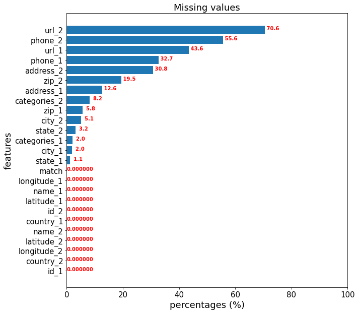

```python
df = df_pairs_us.copy()
# Count the missing values in each feature
missing = df.isna().sum()/df.shape[0]*100
print(missing.sort_values())

# Plot the percentages of missing values for each feature
import matplotlib.ticker as mtick
tmp = df.isna().sum().sort_values()
fig, ax = plt.subplots(figsize=(10,10))

y = tmp/len(df)*100
ax.barh(tmp.index, y)
ax.set_title("Missing values", fontsize=18)
# ax.axvline(x=60,color='r',linestyle='--')
# ax.xaxis.set_major_formatter(mtick.PercentFormatter())
ax.tick_params(axis='both', labelsize=15 )
ax.set_ylabel('features', fontsize=18)
ax.set_xlabel('percentages (%)', fontsize=18)
ax.set_xlim(0,100)

for index, value in enumerate(y):
    if value < 1:
        ax.text(value, index, '{:.6f}'.format(value), color = 'red', fontweight = 'bold')
    else:
        ax.text(value, index, '{:5.1f}'.format(value), color = 'red', fontweight = 'bold')
plt.show()
```

## Data cleaning

```python
df = df_pairs_us.copy()
# reindexing the subset.
df.reset_index(drop=True, inplace=True)
```

```python
# fill missing value with empty string.
df.fillna('', inplace=True)
# df.isna().sum()
```

```python
import string
string_features = ['name_1', 'name_2',
                   'address_1', 'address_2',
                   'city_1', 'city_2',
                   'state_1', 'state_2',
                   'zip_1', 'zip_2',
                   'country_1', 'country_2',
                   'url_1', 'url_2',
                   'phone_1', 'phone_2',
                   'categories_1', 'categories_2']

df[string_features] = df[string_features].fillna('').astype(str).apply(
    lambda x: x.str.lower().str.replace('[{}]'.format(string.punctuation),'',regex=True))

# The original data type of the position_features is already float64
# position_features = ['latitude_1', 'latitude_2', 'longitude_1', 'longitude_2']
# df[position_features] = df[position_features].astype('float64')
# df.head()
```

```python
# two letter US state code from
# https://www.bls.gov/respondents/mwr/electronic-data-interchange/appendix-d-usps-state-abbreviations-and-fips-codes.htm
# saved in state-code.csv
# Notes: Don't be confused with FIPS Code: 56 is not the total; some numbers are missing.

state = pd.read_csv('../data_raw/state-code.csv', header=None)
state.columns=['state','code']
state['state'] = state['state'].str.upper()
state.head()
```

|  | state | code |
| --- | --- | --- |
| 0 | ALABAMA | AL |
| 1 | ALASKA | AK |
| 2 | ARIZONA | AZ |
| 3 | ARKANSAS | AR |
| 4 | CALIFORNIA | CA |

```python
# Unify the format of the state code
print('before unified:')
print(df['state_1'].unique())
print(df['state_2'].unique())
dict_lookup = dict(zip(state['state'],state['code']))
dict_lookup['CALIF']  = 'CA'
# dict_lookup['D.C.']   = 'DC'
dict_lookup['ONNY']  = 'NY'

df['state_1'] = df['state_1'].str.upper()
df['state_2'] = df['state_2'].str.upper()

for x in dict_lookup.keys():

    df.loc[df["state_1"] == x, "state_1"] = dict_lookup[x]
    df.loc[df["state_2"] == x, "state_2"] = dict_lookup[x]

print(78*'*-')
print('after unified:')
print(df['state_1'].unique())
print(df['state_2'].unique())
```

```
before unified:
['ca' 'ga' 'nm' 'fl' 'va' 'tn' 'nj' 'ut' 'in' 'nc' 'wi' '' 'nv' 'ks' 'ma'
 'ms' 'az' 'mi' 'ny' 'tx' 'il' 'al' 'pa' 'ok' 'ar' 'ky' 'mo' 'wv' 'co'
 'ne' 'oh' 'or' 'mt' 'ct' 'nh' 'calif' 'md' 'hi' 'wa' 'wy' 'ri' 'vt' 'ia'
 'mn' 'la' 'sc' 'nd' 'de' 'dc' 'sd' 'ak' 'id' 'me' 'new york'
 'north carolina' 'virginia' 'district of columbia' 'ohio' 'texas'
 'california' 'kentucky' 'ce' 'kansas' 'arizona' 'illinois' 'missouri'
 'onny' 'wisconsin' 'iowa' 'south carolina' 'georgia' 'tennessee'
 'maryland']
['ca' 'ga' 'nm' 'fl' 'va' 'tn' '' 'nj' 'calif' 'ut' 'in' 'nc' 'wi' 'nv'
 'ks' 'ma' 'ms' 'az' 'mi' 'ny' 'tx' 'il' 'al' 'pa' 'ok' 'ar' 'ky' 'wv'
 'co' 'ne' 'oh' 'or' 'mt' 'sc' 'ct' 'nh' 'mo' 'md' 'hi' 'wa' 'wy' 'vt'
 'ia' 'mn' 'la' 'nd' 'de' 'pennsylvania' 'illinois' 'dc' 'sd' 'nevada'
 'ak' 'id' 'me' 'texas' 'arkansas' 'ri' 'new york' 'florida' 'michigan'
 'ohio' 'new jersey' 'connecticut' 'north carolina' 'georgia' 'virginia'
 'colorado' 'california' 'missouri' 'uk' 'louisiana' 'tennessee'
 'delaware' 'wisconsin' 'arizona' 'massachusetts' 'mississippi' 'ce'
 'idaho' 'alabama' 'minnesota' 'oregon' 'indiana' 'iowa' 'west virginia'
 'kansas' 'maryland' 'nu' 'new mexico' 'washington' 'nebraska' 'hawaii'
 'south carolina' 'south dakota' 'oklahoma' 'vermont' 'north dakota' '国外']
*-*-*-*-*-*-*-*-*-*-*-*-*-*-*-*-*-*-*-*-*-*-*-*-*-*-*-*-*-*-*-*-*-*-*-*-*-*-*-*-*-*-*-*-*-*-*-*-*-*-*-*-*-*-*-*-*-*-*-*-*-*-*-*-*-*-*-*-*-*-*-*-*-*-*-*-*-*-
after unified:
['CA' 'GA' 'NM' 'FL' 'VA' 'TN' 'NJ' 'UT' 'IN' 'NC' 'WI' '' 'NV' 'KS' 'MA'
 'MS' 'AZ' 'MI' 'NY' 'TX' 'IL' 'AL' 'PA' 'OK' 'AR' 'KY' 'MO' 'WV' 'CO'
 'NE' 'OH' 'OR' 'MT' 'CT' 'NH' 'MD' 'HI' 'WA' 'WY' 'RI' 'VT' 'IA' 'MN'
 'LA' 'SC' 'ND' 'DE' 'DC' 'SD' 'AK' 'ID' 'ME' 'CE']
['CA' 'GA' 'NM' 'FL' 'VA' 'TN' '' 'NJ' 'UT' 'IN' 'NC' 'WI' 'NV' 'KS' 'MA'
 'MS' 'AZ' 'MI' 'NY' 'TX' 'IL' 'AL' 'PA' 'OK' 'AR' 'KY' 'WV' 'CO' 'NE'
 'OH' 'OR' 'MT' 'SC' 'CT' 'NH' 'MO' 'MD' 'HI' 'WA' 'WY' 'VT' 'IA' 'MN'
 'LA' 'ND' 'DE' 'DC' 'SD' 'AK' 'ID' 'ME' 'RI' 'UK' 'CE' 'NU' '国外']
```

Throw away rows with the `state` codes that are not in `state-code.csv`.

```python
print(set(df['state_1'].unique()).difference(set(state['code'])))
print(set(df['state_2'].unique()).difference(set(state['code'])))
S1 = set(df['state_1'].unique())
S2 = set(df['state_2'].unique())
S  = set(state['code'])
drop_list = S1.union(S2).difference(S)
print(drop_list)
drop_list.remove('')
print(drop_list) # drop_list = ['UK', 'CE', 'NU', '国外']
```

```
{'', 'CE'}
{'', 'NU', 'CE', '国外', 'UK'}
{'', 'NU', 'CE', '国外', 'UK'}
{'NU', 'CE', '国外', 'UK'}
```

```python
df = df[df['state_1'].isin(drop_list)==False]
df = df[df['state_2'].isin(drop_list)==False]
print(df['state_1'].unique())
print(df['state_2'].unique())
tmp1 = df['state_1'].unique()
tmp2 = df['state_2'].unique()
print('state code  missed in state_1:')
print(set(state['code']).difference(set(tmp1)))
print('state code  missed in state_2:')
print(set(state['code']).difference(set(tmp2)))
print(df.shape)
```

```
['CA' 'GA' 'NM' 'FL' 'VA' 'TN' 'NJ' 'UT' 'IN' 'NC' 'WI' '' 'NV' 'KS' 'MA'
 'MS' 'AZ' 'MI' 'NY' 'TX' 'IL' 'AL' 'PA' 'OK' 'AR' 'KY' 'MO' 'WV' 'CO'
 'NE' 'OH' 'OR' 'MT' 'CT' 'NH' 'MD' 'HI' 'WA' 'WY' 'RI' 'VT' 'IA' 'MN'
 'LA' 'SC' 'ND' 'DE' 'DC' 'SD' 'AK' 'ID' 'ME']
['CA' 'GA' 'NM' 'FL' 'VA' 'TN' '' 'NJ' 'UT' 'IN' 'NC' 'WI' 'NV' 'KS' 'MA'
 'MS' 'AZ' 'MI' 'NY' 'TX' 'IL' 'AL' 'PA' 'OK' 'AR' 'KY' 'WV' 'CO' 'NE'
 'OH' 'OR' 'MT' 'SC' 'CT' 'NH' 'MO' 'MD' 'HI' 'WA' 'WY' 'VT' 'IA' 'MN'
 'LA' 'ND' 'DE' 'DC' 'SD' 'AK' 'ID' 'ME' 'RI']
state code  missed in state_1:
{'VI', 'PR'}
state code  missed in state_2:
{'VI', 'PR'}
(117703, 25)
```

No data pairs in Puerto Rico (PR) or Virgin Islands (VI).

## Feature analysis

The available pairs of features include:

```
'name', 'latitude', 'longitude', 'address', 'city', 'state',
       'zip', 'country', 'url', 'phone', 'categories'
```

```python
print(df.columns.values)
```

```
['id_1' 'name_1' 'latitude_1' 'longitude_1' 'address_1' 'city_1' 'state_1'
 'zip_1' 'country_1' 'url_1' 'phone_1' 'categories_1' 'id_2' 'name_2'
 'latitude_2' 'longitude_2' 'address_2' 'city_2' 'state_2' 'zip_2'
 'country_2' 'url_2' 'phone_2' 'categories_2' 'match']
```

### True vs False in the `match` feature

```python
tmp = df.groupby('match')['match'].count()
tmp
```

```
match
False    33096
True     84607
Name: match, dtype: int64
```

```python
print('False/True: {}'.format(tmp.loc[0]/tmp.loc[1]))
```

```
False/True: 0.39117330717316534
```

We can subset the data (randomly) further to make it 50/50.

### Comparing the numeric feature (latitude, longitude)

We compute the L^\infty distance for (latitude, longitude) of each US pair.

- Locations with small distance (less than 0.001) may have different POIs: stores are next to each other in a shopping center. In some extreme cases, places with identical coordinates can have different POI. For example, one classroom can be located vertically on top of another.
- Conversely, locations physically far can represent the same POI, such as mountains.

```python
# Compute the L^\infty difference of (latitude, longitude) of each pair in df_pairs.csv
df['location_diff'] = pd.concat([(df['latitude_1']-df['latitude_2']).abs(),
                                 (df['longitude_1']-df['longitude_2']).abs()], axis=1).max(axis=1)

df.location_diff.describe()
```

```
count    117703.000000
mean          0.087312
std           1.425253
min           0.000000
25%           0.000293
50%           0.001116
75%           0.005862
max         222.460965
Name: location_diff, dtype: float64
```

The following strip plots show that location difference alone is not useful for determining the POI.

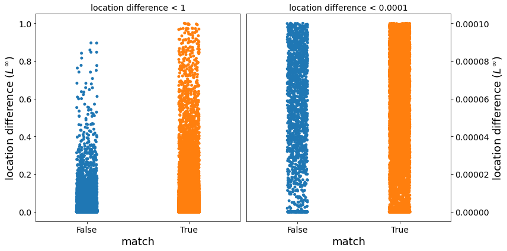

```python
fig, axs = plt.subplots(1,2,figsize = (12,6))
sns.stripplot(x="match", y="location_diff", data=df.loc[df.location_diff<1], ax=axs[0])
axs[0].set_ylabel(r"location difference ($L^\infty$)", fontsize=18)
axs[0].set_xlabel("match", fontsize=18)
axs[0].set_title('location difference < 1',fontsize=14)
axs[0].tick_params(labelsize=14)

sns.stripplot(x="match", y="location_diff", data=df.loc[df.location_diff<0.0001], ax=axs[1])
axs[1].set_ylabel(r"location difference ($L^\infty$)", fontsize=18)
axs[1].set_xlabel("match", fontsize=18)
axs[1].set_title('location difference < 0.0001',fontsize=14)
axs[1].tick_params(labelsize=14)
axs[1].yaxis.tick_right()
axs[1].yaxis.set_label_position("right")
plt.tight_layout()
plt.show()
```

```python
# fig, ax = plt.subplots(figsize = (8,6))
# sns.stripplot(x="match", y="location_diff", data=df.loc[df.location_diff==0],ax=ax)
# ax.set_ylabel(r"location difference", fontsize=18)
# ax.set_xlabel("match", fontsize=18)
# ax.tick_params(labelsize=14)
# plt.show()
```

```python
def myprint(eps):
    tmp = len(df.loc[(df.location_diff<=eps) & (df.match==False)])
    total = len(df)
    if eps == 0:
        print('There are {:5d} (US) pairs with location difference ={:.5f} but different POIs, out of all {:2.2f}% (US) pairs.'.format(
          tmp, eps, tmp*100/total))
    else:
        print('There are {:5d} (US) pairs with location difference<={:.5f} but different POIs, out of all {:2.2f}% (US) pairs.'.format(
          tmp, eps, tmp*100/total))

myprint(1)
myprint(0.0001)
myprint(0)
```

```
There are 33005 (US) pairs with location difference<=1.00000 but different POIs, out of all 28.04% (US) pairs.
There are  1639 (US) pairs with location difference<=0.00010 but different POIs, out of all 1.39% (US) pairs.
There are   146 (US) pairs with location difference =0.00000 but different POIs, out of all 0.12% (US) pairs.
```

```python
# print('There are',len(df.loc[(df.location_diff==0) & (df.match==False)]),
#       'df_pairs with location_diff=0 but different POIs, out of all',len(df_pairs),'df_pairs.')
```

### straight line distance and angular (great circle) distance

```python
def get_diff(df,func,*feature,name=None,sim=None):
    '''Get difference of given feature using input metric

    df:      data frame of pairs
    func:    metric to apply
    feature: features to compare with the metric
    name:    new feature name

    '''
    if name is None:
        name = feature[0]+'_diff'
    if sim is None:
        sim = 'difference'
    else:
        sim = 'similarity'

    print('Getting {} in {} with the "{}" metric.'.format(sim,feature,func.__name__))

    print('Making new column "{}"'.format(name))
    print()
    cols = [str(x)+'_1' for x in feature]+[str(x)+'_2' for x in feature]
    df[name] = df[cols].apply(func, axis=1)
```

```python
def l2_metric(pair):
    ''' Euclidean distance (l2) for comparing geographic coordinates

    '''
    a = np.asarray(pair[0],pair[1])
    b = np.asarray(pair[2],pair[3])
    return np.linalg.norm(a-b)
```

```python
def theta_diff(pair):
    ''' Great circle distance for geographic coordinates

    https://en.wikipedia.org/wiki/Great-circle_distance#Computational_formulas

    '''
    PI = np.pi

    phi_1, phi_2 = pair[0], pair[1] #latitudes
    lam_1, lam_2 = pair[2], pair[3] #longitudes

    # convert to radians for calculation:
    for x in [phi_1,phi_2,lam_1,lam_2]:
        x = np.deg2rad(x)

    del_lam = lam_1 - lam_2

    p = np.cos(phi_2)*np.sin(del_lam)
    q = np.cos(phi_1)*np.sin(phi_2) - np.sin(phi_1)*np.cos(phi_2)*np.cos(del_lam)
    r = np.sin(phi_1)*np.sin(phi_2) + np.cos(phi_1)*np.cos(phi_2)*np.cos(del_lam)

    diff = np.arctan(np.sqrt(p**2+q**2)/r)

    return np.abs(diff)
```

```python
feature = ('latitude','longitude')
get_diff(df,l2_metric,*feature,name='geo_diff')
get_diff(df,theta_diff,*feature,name='geo_theta_diff')
```

```
Getting difference in ('latitude', 'longitude') with the "l2_metric" metric.
Making new column "geo_diff"

Getting difference in ('latitude', 'longitude') with the "theta_diff" metric.
Making new column "geo_theta_diff"
```

```python
print(df.columns.values)
```

```
['id_1' 'name_1' 'latitude_1' 'longitude_1' 'address_1' 'city_1' 'state_1'
 'zip_1' 'country_1' 'url_1' 'phone_1' 'categories_1' 'id_2' 'name_2'
 'latitude_2' 'longitude_2' 'address_2' 'city_2' 'state_2' 'zip_2'
 'country_2' 'url_2' 'phone_2' 'categories_2' 'match' 'location_diff'
 'geo_diff' 'geo_theta_diff']
```

```python
# ### name

#   * There are some true pairs with slightly different names, e.g. short name v.s. full name.
#   * Conversely, there are false pairs with the same name, e.g. chain stores in different cities.
```

```python
# df.loc[df.match==True,['name_1','name_2','match']].sample(20)
```

### Comparing string features using different metrics

Most columns in this data are strings. We consider different metrics for string comparison letter by letter, including:

- `SequenceMatcher`
- `Levenshtein distance`

or word by word using

- `CountVectorizer` and `cosine_similarity`

```python
def l2_metric(pair):
    ''' Euclidean distance (l2) for comparing geographic coordinates

    '''
    a = np.asarray(pair[0],pair[1])
    b = np.asarray(pair[2],pair[3])
    return np.linalg.norm(a-b)
```

```python
from difflib import SequenceMatcher
def seq_metric(pair):
    ''' metric for comparing strings

    '''
    a,b = tuple(pair)
    if type(a)!=str or type(b)!=str:
        return -1
    else:
        # from Ling.
        a = a.lower().replace(" ", "").replace("'", "")
        b = b.lower().replace(" ", "").replace("'", "")
        # b = b.lower().replace('[{}]'.format(string.punctuation),'').replace(" ", "")
    return 1-SequenceMatcher(None, a, b).ratio()
```

```python
from Levenshtein import distance as lev
def lev_metric(pair):
    ''' Levenshtein metric for comparing strings

    '''
    a,b = tuple(pair)
    if type(a)!=str or type(b)!=str:
        return -1
    elif len(a)==0 or len(b)==0:
        return -1
    else:
        a = a.lower().replace(" ", "").replace("'", "")
        b = b.lower().replace(" ", "").replace("'", "")
    return lev(a,b)/max(len(a),len(b))
```

```python
print(df.columns.values)
print()

feature = ('latitude','longitude')
get_diff(df,l2_metric,*feature,name='geo_diff')

features = ['name','address','city','state','zip','url','phone','categories']
features = [[x] for x in features]
for feature in features:
    get_diff(df,seq_metric,*feature,name=feature[0]+'_diff_seq')
    get_diff(df,lev_metric,*feature,name=feature[0]+'_diff_lev')
print(df.columns.values)
```

```
['id_1' 'name_1' 'latitude_1' 'longitude_1' 'address_1' 'city_1' 'state_1'
 'zip_1' 'country_1' 'url_1' 'phone_1' 'categories_1' 'id_2' 'name_2'
 'latitude_2' 'longitude_2' 'address_2' 'city_2' 'state_2' 'zip_2'
 'country_2' 'url_2' 'phone_2' 'categories_2' 'match' 'location_diff'
 'geo_diff' 'geo_theta_diff']

Getting difference in ('latitude', 'longitude') with the "l2_metric" metric.
Making new column "geo_diff"

Getting difference in ('name',) with the "seq_metric" metric.
Making new column "name_diff_seq"

Getting difference in ('name',) with the "lev_metric" metric.
Making new column "name_diff_lev"

Getting difference in ('address',) with the "seq_metric" metric.
Making new column "address_diff_seq"

Getting difference in ('address',) with the "lev_metric" metric.
Making new column "address_diff_lev"

Getting difference in ('city',) with the "seq_metric" metric.
Making new column "city_diff_seq"

Getting difference in ('city',) with the "lev_metric" metric.
Making new column "city_diff_lev"

Getting difference in ('state',) with the "seq_metric" metric.
Making new column "state_diff_seq"

Getting difference in ('state',) with the "lev_metric" metric.
Making new column "state_diff_lev"

Getting difference in ('zip',) with the "seq_metric" metric.
Making new column "zip_diff_seq"

Getting difference in ('zip',) with the "lev_metric" metric.
Making new column "zip_diff_lev"

Getting difference in ('url',) with the "seq_metric" metric.
```

[output cut: 11 more lines]

```
Getting difference in ('categories',) with the "seq_metric" metric.
Making new column "categories_diff_seq"

Getting difference in ('categories',) with the "lev_metric" metric.
Making new column "categories_diff_lev"

['id_1' 'name_1' 'latitude_1' 'longitude_1' 'address_1' 'city_1' 'state_1'
 'zip_1' 'country_1' 'url_1' 'phone_1' 'categories_1' 'id_2' 'name_2'
 'latitude_2' 'longitude_2' 'address_2' 'city_2' 'state_2' 'zip_2'
 'country_2' 'url_2' 'phone_2' 'categories_2' 'match' 'location_diff'
 'geo_diff' 'geo_theta_diff' 'name_diff_seq' 'name_diff_lev'
 'address_diff_seq' 'address_diff_lev' 'city_diff_seq' 'city_diff_lev'
 'state_diff_seq' 'state_diff_lev' 'zip_diff_seq' 'zip_diff_lev'
 'url_diff_seq' 'url_diff_lev' 'phone_diff_seq' 'phone_diff_lev'
 'categories_diff_seq' 'categories_diff_lev']
```

```python
from sklearn.feature_extraction.text import CountVectorizer
from sklearn.metrics.pairwise import cosine_similarity
import string

def cos_sim(pair):
    ''' cosine_sim metric for comparing strings

    '''
    a,b = tuple(pair)

    try:
        if (a == '') | (b == ''):
            csim = -1
        elif (a == ' ') | (b == ' '):
            csim = -1
        else:
            csim = cosine_similarity(CountVectorizer().fit_transform([a,b]).toarray())[0][1]
        return csim
    except ValueError:
        print(a,b)
        csim = -1
        return csim

features = ['name','address','city','state','zip','url','phone','categories']
features = [[x] for x in features]
for feature in features:
    get_diff(df,cos_sim,*feature,name=feature[0]+'_csim')
print(df.columns.values)
```

```
Getting difference in ('name',) with the "cos_sim" metric.
Making new column "name_csim"

Getting difference in ('address',) with the "cos_sim" metric.
Making new column "address_csim"

1 1
n
Getting difference in ('city',) with the "cos_sim" metric.
Making new column "city_csim"

1 1
Getting difference in ('state',) with the "cos_sim" metric.
Making new column "state_csim"

Getting difference in ('zip',) with the "cos_sim" metric.
Making new column "zip_csim"

Getting difference in ('url',) with the "cos_sim" metric.
Making new column "url_csim"

Getting difference in ('phone',) with the "cos_sim" metric.
Making new column "phone_csim"

0 0
Getting difference in ('categories',) with the "cos_sim" metric.
Making new column "categories_csim"

['id_1' 'name_1' 'latitude_1' 'longitude_1' 'address_1' 'city_1' 'state_1'
 'zip_1' 'country_1' 'url_1' 'phone_1' 'categories_1' 'id_2' 'name_2'
 'latitude_2' 'longitude_2' 'address_2' 'city_2' 'state_2' 'zip_2'
 'country_2' 'url_2' 'phone_2' 'categories_2' 'match' 'location_diff'
 'geo_diff' 'geo_theta_diff' 'name_diff_seq' 'name_diff_lev'
 'address_diff_seq' 'address_diff_lev' 'city_diff_seq' 'city_diff_lev'
 'state_diff_seq' 'state_diff_lev' 'zip_diff_seq' 'zip_diff_lev'
 'url_diff_seq' 'url_diff_lev' 'phone_diff_seq' 'phone_diff_lev'
 'categories_diff_seq' 'categories_diff_lev' 'name_csim' 'address_csim'
 'city_csim' 'state_csim' 'zip_csim' 'url_csim' 'phone_csim'
 'categories_csim']
```

```python
df.columns
```

```
Index(['id_1', 'name_1', 'latitude_1', 'longitude_1', 'address_1', 'city_1',
       'state_1', 'zip_1', 'country_1', 'url_1', 'phone_1', 'categories_1',
       'id_2', 'name_2', 'latitude_2', 'longitude_2', 'address_2', 'city_2',
       'state_2', 'zip_2', 'country_2', 'url_2', 'phone_2', 'categories_2',
       'match', 'location_diff', 'geo_diff', 'geo_theta_diff', 'name_diff_seq',
       'name_diff_lev', 'address_diff_seq', 'address_diff_lev',
       'city_diff_seq', 'city_diff_lev', 'state_diff_seq', 'state_diff_lev',
       'zip_diff_seq', 'zip_diff_lev', 'url_diff_seq', 'url_diff_lev',
       'phone_diff_seq', 'phone_diff_lev', 'categories_diff_seq',
       'categories_diff_lev', 'name_csim', 'address_csim', 'city_csim',
       'state_csim', 'zip_csim', 'url_csim', 'phone_csim', 'categories_csim'],
      dtype='object')
```

### Histogram: SequenceMatcher vs Levenshtein

The histograms show that Levenshtein has more accuracy.

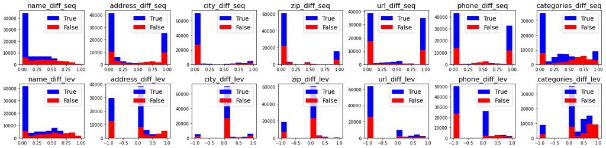

```python
## histograms for SequenceMatcher

columns = ['location_diff',
           'name_diff_seq','address_diff_seq','city_diff_seq',
           'zip_diff_seq','url_diff_seq', 'phone_diff_seq', 'categories_diff_seq',
           'name_diff_lev','address_diff_lev','city_diff_lev',
           'zip_diff_lev','url_diff_lev', 'phone_diff_lev', 'categories_diff_lev',
           'match']

df_pairs_seq = df[columns].copy()

fig, axs = plt.subplots(2,7,figsize=(20,5))
columns = np.array(columns[1:-1]).reshape(2,-1)
for i in range(2):
    for j in range(7):
        column=columns[i,j]
        axs[i,j].hist(df_pairs_seq.loc[(df_pairs_seq.match==True)&(df_pairs_seq.location_diff<1), column], color='b', label="True")
        axs[i,j].hist(df_pairs_seq.loc[(df_pairs_seq.match==False)&(df_pairs_seq.location_diff<1), column], color='r', label="False")
        axs[i,j].legend(fontsize=14)
        axs[i,j].set_title(column,fontsize=16)
        # print(np.array2string(column))

plt.tight_layout()
plt.show()
```

```python
# ## histograms for SequenceMatcher

# columns = ['location_diff','name_diff_seq','address_diff_seq','city_diff_seq',
#            'zip_diff_seq','url_diff_seq', 'phone_diff_seq', 'categories_diff_seq','match']
# df_pairs_seq = df[columns].copy()

# fig, axs = plt.subplots(2,4,figsize=(20,10))
# columns = np.array(columns[:-1]).reshape(2,-1)
# for i in range(2):
#     for j in range(4):
#         column=columns[i,j]
#         axs[i,j].hist(df_pairs_seq.loc[(df_pairs_seq.match==True)&(df_pairs_seq.location_diff<1), column], color='b', label="True")
#         axs[i,j].hist(df_pairs_seq.loc[(df_pairs_seq.match==False)&(df_pairs_seq.location_diff<1), column], color='r', label="False")
#         axs[i,j].legend(fontsize=14)
#         axs[i,j].set_title(column,fontsize=16)
#         # print(np.array2string(column))

# plt.tight_layout()
# plt.show()
```

```python
# # Histogram for Levenshtein distance

# # columns = ['location_diff','name_diff','address_diff','city_diff','zip_diff','url_diff', 'phone_diff', 'categories_diff']

# # for i in range(len(columns)):
# #     column=columns[i]
# #     plt.hist(df_pairs_lev.loc[(df_pairs_lev.match==True)&(df_pairs_lev.location_diff<1), column], color='b', label="True")
# #     plt.hist(df_pairs_lev.loc[(df_pairs_lev.match==False)&(df_pairs_lev.location_diff<1), column], color='r', label="False")
# #     plt.legend(fontsize=14)
# #     plt.title(column,fontsize=16)
# #     plt.show()

# ## histograms for SequenceMatcher

# columns = ['location_diff','name_diff_lev','address_diff_lev','city_diff_lev',
#            'zip_diff_lev','url_diff_lev', 'phone_diff_lev', 'categories_diff_lev','match']
# df_pairs_seq = df[columns].copy()

# fig, axs = plt.subplots(2,4,figsize=(20,10))
# columns = np.array(columns[:-1]).reshape(2,-1)
# for i in range(2):
#     for j in range(4):
#         column=columns[i,j]
#         axs[i,j].hist(df_pairs_seq.loc[(df_pairs_seq.match==True)&(df_pairs_seq.location_diff<1), column], color='b', label="True")
#         axs[i,j].hist(df_pairs_seq.loc[(df_pairs_seq.match==False)&(df_pairs_seq.location_diff<1), column], color='r', label="False")
#         axs[i,j].legend(fontsize=14)
#         axs[i,j].set_title(column,fontsize=16)
#         # print(np.array2string(column))

# plt.tight_layout()
# plt.show()
```

## Tim Prep for Cosine Similarities: Filling NAs and Making Combined Full Addresses

```python
df_pairs['categories_1']   = df_pairs['categories_1'].fillna('')
df_pairs['categories_2']   = df_pairs['categories_2'].fillna('')
df_pairs['full_address_1'] = df_pairs['address_1'].fillna('') + ' ' + df_pairs['city_1'].fillna('') + ' ' + df_pairs['state_1'].fillna('') + ' ' + df_pairs['zip_1'].fillna('')  + ' ' + df_pairs['country_1'].fillna('')
```

```python
df_pairs['full_address_1'] = df_pairs['address_1'].fillna('') + ' ' + df_pairs['city_1'].fillna('') + ' ' + df_pairs['state_1'].fillna('') + ' ' + df_pairs['zip_1'].fillna('')  + ' ' + df_pairs['country_1'].fillna('')
df_pairs['full_address_2'] = df_pairs['address_2'].fillna('') + ' ' + df_pairs['city_2'].fillna('') + ' ' + df_pairs['state_2'].fillna('') + ' ' + df_pairs['zip_2'].fillna('')  + ' ' + df_pairs['country_2'].fillna('')
```